# Predicting Spotify Song Genre

### Modeling

```r
features <-as.data.frame(spotify[,c(4,10,12:24)])
head(features)
```

```
##   track_popularity playlist_genre danceability energy key loudness mode
## 1               66            pop        0.748  0.916   6   -2.634    1
## 2               67            pop        0.726  0.815  11   -4.969    1
## 3               70            pop        0.675  0.931   1   -3.432    0
## 4               60            pop        0.718  0.930   7   -3.778    1
## 5               69            pop        0.650  0.833   1   -4.672    1
## 6               67            pop        0.675  0.919   8   -5.385    1
##   speechiness acousticness instrumentalness liveness valence   tempo
## 1      0.0583       0.1020         0.00e+00   0.0653   0.518 122.036
## 2      0.0373       0.0724         4.21e-03   0.3570   0.693  99.972
## 3      0.0742       0.0794         2.33e-05   0.1100   0.613 124.008
## 4      0.1020       0.0287         9.43e-06   0.2040   0.277 121.956
## 5      0.0359       0.0803         0.00e+00   0.0833   0.725 123.976
## 6      0.1270       0.0799         0.00e+00   0.1430   0.585 124.982
##   duration_ms track_year
## 1      194754       2019
## 2      162600       2019
## 3      176616       2019
## 4      169093       2019
## 5      189052       2019
## 6      163049       2019
```

#### Regression

As discussed in our objective that we intendt to predict the track popularity of the spotify songs dataset and with tarck_popularity being a continuous variable, we applied linear regression to the model.

```r
sample_size1=floor(0.7*nrow(features))
set.seed(123)
df_train1= sample(seq_len(nrow(features)),size = sample_size1)
train1=features[df_train1,]
test1=features[-df_train1,]
spotify.lm<-lm(track_popularity ~.,data=train1)
summary(spotify.lm)
```

```
##
## Call:
## lm(formula = track_popularity ~ ., data = train1)
##
## Residuals:
##     Min      1Q  Median      3Q     Max
## -62.341 -17.259   3.228  18.547  64.213
##
## Coefficients:
##                       Estimate Std. Error t value Pr(>|t|)
## (Intercept)          2.586e+01  3.764e+01   0.687 0.492076
## playlist_genrelatin  8.979e+00  5.873e-01  15.290  < 2e-16 ***
## playlist_genrepop    1.050e+01  5.635e-01  18.624  < 2e-16 ***
## playlist_genrer&b    3.439e+00  6.122e-01   5.617 1.97e-08 ***
## playlist_genrerap    4.690e+00  5.968e-01   7.858 4.07e-15 ***
## playlist_genrerock   1.021e+01  6.817e-01  14.976  < 2e-16 ***
## danceability         9.176e+00  1.357e+00   6.763 1.39e-11 ***
## energy              -2.937e+01  1.471e+00 -19.970  < 2e-16 ***
## key                  4.887e-02  4.417e-02   1.106 0.268593
## loudness             1.570e+00  8.042e-02  19.523  < 2e-16 ***
## mode                 1.987e-01  3.246e-01   0.612 0.540559
## speechiness         -2.601e+00  1.770e+00  -1.470 0.141619
## acousticness         2.968e+00  8.763e-01   3.387 0.000707 ***
## instrumentalness    -9.083e+00  7.732e-01 -11.747  < 2e-16 ***
## liveness            -2.983e+00  1.045e+00  -2.854 0.004322 **
## valence             -4.361e-01  8.180e-01  -0.533 0.593984
## tempo                2.222e-02  6.078e-03   3.655 0.000257 ***
## duration_ms         -4.550e-05  2.831e-06 -16.073  < 2e-16 ***
## track_year           2.200e-02  1.843e-02   1.193 0.232692
## ---
## Signif. codes:  0 '***' 0.001 '**' 0.01 '*' 0.05 '.' 0.1 ' ' 1
##
## Residual standard error: 23.81 on 22964 degrees of freedom
## Multiple R-squared:  0.09423,    Adjusted R-squared:  0.09352
## F-statistic: 132.7 on 18 and 22964 DF,  p-value: < 2.2e-16
```

What we witnessed here is despite most variables that were considered in the model were significant but the r square value of the model is extremely low. R square value tells us how accurately our dependent variable which is track_popularity in our model is explained by other independent variables.

An extremely low r square of our model signifies that linear regression is not an accurate approach for our problem statement.

#### Classification

##### **Logistic**

Now after witnessing the drawback with linear regression we thought of applying logistic regression and predict the genre instead of track popularity.

In the below code we have just added a numeric genre_encode column with rap,rock and latin classified as ‘0’ and r&b,edm and pop classified as ‘1’

```r
features[which(features$playlist_genre=='rap'|features$playlist_genre=='rock'|features$playlist_genre=='latin'),"genre_encode"] <- 0
features[which(features$playlist_genre=='pop'|features$playlist_genre=='r&b'|features$playlist_genre=='edm'),"genre_encode"] <- 1
features<-features[,-2]
head(features)
```

```
##   track_popularity danceability energy key loudness mode speechiness
## 1               66        0.748  0.916   6   -2.634    1      0.0583
## 2               67        0.726  0.815  11   -4.969    1      0.0373
## 3               70        0.675  0.931   1   -3.432    0      0.0742
## 4               60        0.718  0.930   7   -3.778    1      0.1020
## 5               69        0.650  0.833   1   -4.672    1      0.0359
## 6               67        0.675  0.919   8   -5.385    1      0.1270
##   acousticness instrumentalness liveness valence   tempo duration_ms track_year
## 1       0.1020         0.00e+00   0.0653   0.518 122.036      194754       2019
## 2       0.0724         4.21e-03   0.3570   0.693  99.972      162600       2019
## 3       0.0794         2.33e-05   0.1100   0.613 124.008      176616       2019
## 4       0.0287         9.43e-06   0.2040   0.277 121.956      169093       2019
## 5       0.0803         0.00e+00   0.0833   0.725 123.976      189052       2019
## 6       0.0799         0.00e+00   0.1430   0.585 124.982      163049       2019
##   genre_encode
## 1            1
## 2            1
## 3            1
## 4            1
## 5            1
## 6            1
```

```r
sample_size=floor(0.7*nrow(features))
set.seed(123)
df_train= sample(seq_len(nrow(features)),size = sample_size)
train=features[df_train,]
test=features[-df_train,]
colnames(train)
```

```
##  [1] "track_popularity" "danceability"     "energy"           "key"
##  [5] "loudness"         "mode"             "speechiness"      "acousticness"
##  [9] "instrumentalness" "liveness"         "valence"          "tempo"
## [13] "duration_ms"      "track_year"       "genre_encode"
```

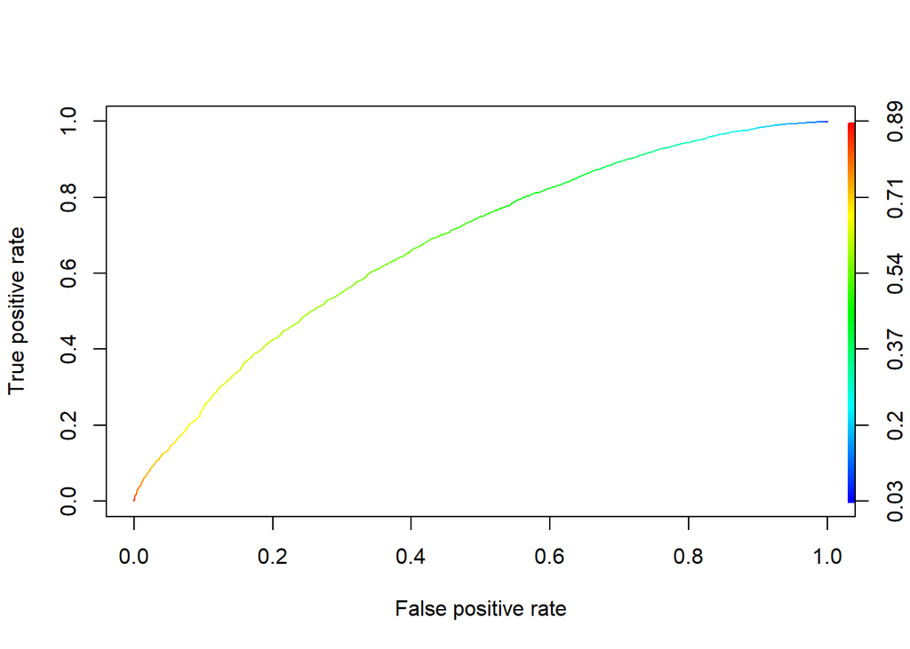

```r
spotify.glm<-glm(genre_encode ~.,family ='binomial',data=train)
pred.glm.test<- predict(spotify.glm, newdata = test, type="response")
pred<-prediction(pred.glm.test,test$genre_encode)
perf<-performance(pred,"tpr","fpr")
plot(perf,colorize=TRUE)
```

```r
unlist(slot(performance(pred, "auc"), "y.values"))
```

```
## [1] 0.6810062
```

```r
pcut1<- mean(train$genre_encode)
pcut1
```

```
## [1] 0.5190793
```

```r
predict.test <- predict(spotify.glm, newdata=test,type = "response")
pred.test <- as.numeric(predict.test > pcut1)
confusion_matrix_test <- table(test$genre_encode, pred.test,dnn=c("True","Predicted"))
confusion_matrix_test
```

```
##     Predicted
## True    0    1
##    0 2631 2168
##    1 1483 3568
```

```r
misclassification_rate_test <-round((confusion_matrix_test[2]+confusion_matrix_test[3])/sum(confusion_matrix_test), 2)
misclassification_rate_test
```

```
## [1] 0.37
```

After running the above set of codes we have received an accuracy of 63%.

##### **Decision Tree**

```r
spotify.rpart<- rpart(formula = genre_encode ~ ., data = train, method = "class")
spotify.rpart
```

```
## n= 22983
##
## node), split, n, loss, yval, (yprob)
##       * denotes terminal node
##
##  1) root 22983 11053 1 (0.4809207 0.5190793)
##    2) track_year< 2009.5 6210  2080 0 (0.6650564 0.3349436) *
##    3) track_year>=2009.5 16773  6923 1 (0.4127467 0.5872533)
##      6) speechiness>=0.1005 5601  2612 0 (0.5336547 0.4663453)
##       12) instrumentalness< 1.915e-05 3485  1358 0 (0.6103300 0.3896700) *
##       13) instrumentalness>=1.915e-05 2116   862 1 (0.4073724 0.5926276) *
##      7) speechiness< 0.1005 11172  3934 1 (0.3521303 0.6478697) *
```

```r
spotify.train.pred.tree1<- predict(spotify.rpart, type="class")
table(train$genre_encode, spotify.train.pred.tree1, dnn = c("True", "Pred"))
```

```
##     Pred
## True    0    1
##    0 6257 4796
##    1 3438 8492
```

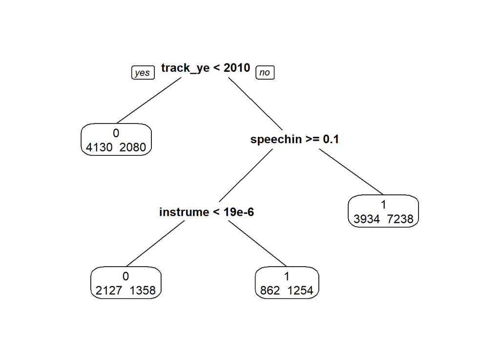

```r
prp(spotify.rpart, extra = 1)
```

```r
spotify.test.pred.tree1<- predict(spotify.rpart, test, type="class")
table(test$genre_encode, spotify.test.pred.tree1, dnn=c("Truth","Predicted"))
```

```
##      Predicted
## Truth    0    1
##     0 2713 2086
##     1 1446 3605
```

```r
cost <- function(r, pi){
  weight1 = 1
  weight0 = 1
  c1 = (r==1)&(pi==0) #logical vector - true if actual 1 but predict 0
  c0 = (r==0)&(pi==1) #logical vector - true if actual 0 but predict 1
  return(mean(weight1*c1+weight0*c0))
}
cost(train$genre_encode,spotify.train.pred.tree1)
```

```
## [1] 0.3582648
```

```r
cost(test$genre_encode,spotify.test.pred.tree1)
```

```
## [1] 0.3585787
```

After running the above set of codes we have received an accuracy of 64%.

### Summary

- The whole approach of our project was to predict track_popularity. But gradually after closely understanding the data through Exploratory Data Analysis and running regression which is one of the modeling techniques we realized that track_popularity is too difficult to predict as the linear relationship between dependent and independent variables is not accurately explained.
- Also from the API documentation of Spotify which can be found [here](https://developer.spotify.com/documentation/web-api/reference/tracks/get-track/) it indicates that track_popularity is calculated by the total number of plays and how recent those plays were. So after doing quick secondary research, we have witnessed that the linear regression approach is not an accurate approach for our problem statement and hence we switched to logistic regression.
- In this approach we classified song_genre into two classes; with rap, rock and latin in class ‘0’ and r&b,edm and pop in class ‘1’. So now the objective of predicting the class of song_genre was achieved with an accuracy of 63%, the same appraoch was further verified by applying decision tree apprach which resulted in improving accuracy by 1% i.e at 64%